# Phylogeography using ancestral reconstruction

By reconstructing the ancestral geographic ranges of strains or lineages at different points in their evolutionary history, ancestral reconstruction methods help infer the spatial dynamics of population divergence. These reconstructions integrate phylogenetic trees and geographical data and enable researchers to trace the origins and migration of populations or the spread of disease.

Here we will use the ‘ace’ function in the R package ‘ape’ to carry out ancestral reconstruction of the location of strains throughout the timed phylogeny from the P1 SARS-CoV-2 strains in the Pacific Northwest. This will help to track the variant and identify times when there may have been a migration between states and countries.

The data files we will be using are:

- P1_timetree.tree - The timed phylogeny of P1 SARS-CoV-2 sequences collected from the Pacific Northwest that were downloaded from GISAID
- P1_dates_location.csv - A file containing the dates and locations of all P1 SARS-CoV-2 sequences

#### 1. First we will set up the packages and options:

```r
# Install and load required packages
if (!requireNamespace("ape", quietly = TRUE)) {
  install.packages("ape")
}
if (!requireNamespace("phytools", quietly = TRUE)) {
  install.packages("phytools")
}
if (!requireNamespace("ggalluvial", quietly = TRUE)) {
  install.packages("ggalluvial")
}
if (!requireNamespace("ggplot2", quietly = TRUE)) {
  install.packages("ggplot2")
}
if (!requireNamespace("tibble", quietly = TRUE)) {
  install.packages("tibble")
}
if (!requireNamespace("dplyr", quietly = TRUE)) {
  install.packages("dplyr")
}
if (!requireNamespace("tidyr", quietly = TRUE)) {
  install.packages("tidyr")
}
library(ape)
library(tibble)
library(dplyr)
library(tidyr)
library(phytools)
library(ggalluvial)
library(ggplot2)
library(ggtree)
options(stringsAsFactors = F)
```

#### 2. Load in the timed phylogeny. We will remove the Wuhan 1 reference sequence from the tree as we are only concerned with the ancestral movements of the P1 variant.

```r
# Load the timed phylogenetic tree
tree <- read.tree("P1_timetree.tree")
tree <- drop.tip(tree,"MN908947.3")
```

#### 3. Read the location data into R. Again, only use metadata for sequences in the tree.

```r
Metadata <- read.csv("P1_dates_location.csv")
Metadata <- Metadata[which(Metadata$Name %in% tree$tip.label),]
```

#### 4. Make a vector of the locations only and name this vector as the sequence names.

```r
Location<-Metadata$Location
names(Location)<-Metadata$Name
```

#### 5. As with some of the earlier analyses, ancestral reconstruction requires a bifuricating tree so we can test for multifurication and make it bifuricating, and make any zero branch lengths a small non-zero value.

```r
if (!is.binary(tree)){# if not bifuricating tree
  tree=multi2di(tree) # Change to bifuricating
  tree$edge.length[which(tree$edge.length==0)]<-0.000000000001 # make all branch length non-zero
}
```

#### 6. Now we can run the ancestral reconstruction using the ‘ace’ function. The method we will use is “ML”, which stands for maximum likelihood and the type of data is discrete “d”.

```r
anc_Location<-suppressWarnings(ace(Location,tree, type="d", method = "ML"))
```

#### 7. The result will be a list of 6 objects including a matrix of the likelihoods of each ancestral location at each node (anc_location$lik.anc). Here we will find the location for each node that has the highest likelihood and assign it to a names vector.

```r
## infer the most likely ancestral location of each node
node_anc <- colnames(anc_Location$lik.anc)[apply(anc_Location$lik.anc, 1, which.max)]
names(node_anc)<-row.names(anc_Location$lik.anc)
```

#### 8. We can plot the inferred location at each node on the tree. We first need to make a new vector of colours for each location and then use ggtree to plot.

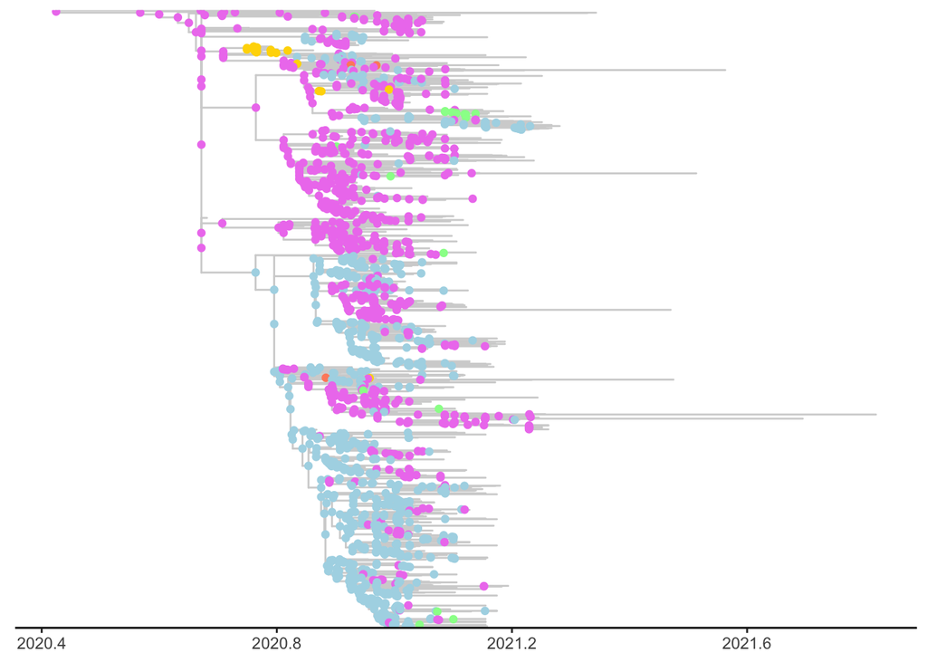

```r
node_anc_colors <- node_anc
node_anc_colors[which(node_anc_colors=="Washington")]<-"violet"
node_anc_colors[which(node_anc_colors=="Oregon")]<-"lightblue"
node_anc_colors[which(node_anc_colors=="Montana")]<-"palegreen"
node_anc_colors[which(node_anc_colors=="Alberta")]<-"salmon1"
node_anc_colors[which(node_anc_colors=="BritishColumbia")]<-"gold"

## Plot using ggtree
ggtree(tree,right=TRUE, mrsd = max(Metadata$Date),color="lightgrey") +
  geom_nodepoint(color=node_anc_colors) + theme_tree2()
```

#### *Question: Around what time does it look like P1 first entered BC? From where?*

#### 9. Now let’s make a data frame of the location at each node and tip, and the location at the previous node. This way we can then identify nodes in which there has been a change in location.

```r
melt_tree<-as_tibble(tree)
Location_changes<-data.frame(Origin=melt_tree$parent,Destination=melt_tree$node)
for (i in 1:length(Location)){
  Location_changes$Origin[i]<-node_anc[which(names(node_anc)==Location_changes$Origin[i])]
  Location_changes$Destination[i]<-Location[which(names(Location)==melt_tree$label[i])]
}
for (i in (length(Location)+1):nrow(Location_changes)){
  Location_changes$Origin[i]<-node_anc[which(names(node_anc)==Location_changes$Origin[i])]
  Location_changes$Destination[i]<-node_anc[which(names(node_anc)==Location_changes$Destination[i])]
}
```

#### 10. We need to transform the data into a format that can be used to make our final plot.

```r
## Make result data frame summarizing the number of movements between and within locations.
result <- Location_changes %>%
  group_by(Origin, Destination) %>%
  summarize(freq = n()) %>%
  ungroup()
head(result)
```

```
## # A tibble: 6 × 3
##   Origin          Destination      freq
##   <chr>           <chr>           <int>
## 1 Alberta         Alberta             4
## 2 Alberta         BritishColumbia     1
## 3 Alberta         Oregon              1
## 4 BritishColumbia BritishColumbia    49
## 5 BritishColumbia Washington          1
## 6 Montana         Montana            37
```

```r
## Transform the data into the alluvial format
alluvial_data <- pivot_longer(result, cols = c(Origin, Destination),
                        names_to = "Direction", values_to = "Location") %>%
  group_by(Direction) %>%
  mutate(row = row_number()) %>%
  select(Direction, Location, row, freq)

alluvial_data$Location <- as.factor(alluvial_data$Location) # Make location a factor
```

#### 11. Finally we can make an alluvial plot with the package ‘ggalluvial’ to show all the inferred movements between nodes. This can give us a visual representation of the migration.

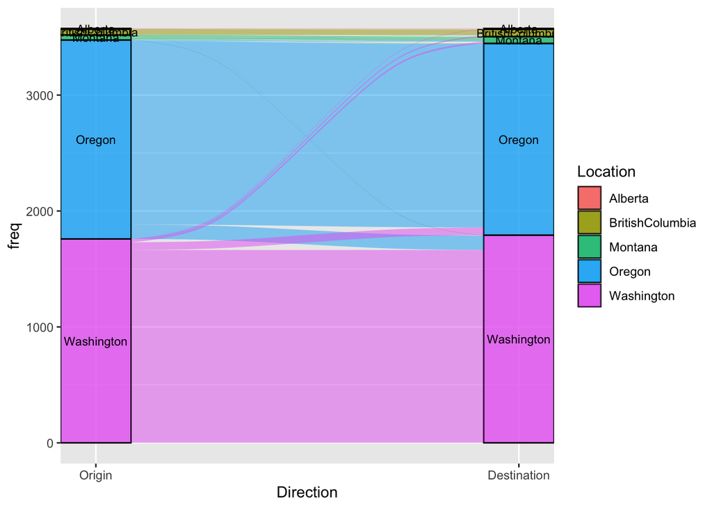

```r
ggplot(alluvial_data,
       aes(x=Direction, stratum = Location, y = freq,
           fill=Location, alluvium=row, label=Location)) +
  geom_stratum(width = 1/6, alpha=0.8) +
  geom_flow(width = 1/6)+
  geom_text(stat = "stratum", size=3, min.y = 1) +
  scale_x_discrete(limits = c("Origin", "Destination"), expand = c(.01, .01))
```

#### *Question: Where does it seem like the majority of cases have come from in the Pacific northwest?*

### Next activity: [Homoplasy analysis to identify sites under selection](https://bensobkowiak.github.io/GenomicsCourse/Practicals/Homoplasy.html)